# San Mateo-Foster City

## List of active schools

#### Preschool

- San Mateo-Foster City Special Education Preschool

#### Elementary

- Audubon Elementary
- Baywood Elementary
- Beresford Elementary
- Brewer Island Elementary
- College Park Elementary
- Fiesta Gardens International Elementary
- Foster City Elementary
- George Hall Elementary
- Highlands Elementary
- Laurel Elementary
- LEAD Elementary
- Meadow Heights Elementary
- North Shoreview Montessori Elementary
- Parkside Elementary
- San Mateo Park Elementary
- Sunnybrae Elementary

#### Intermediate/Middle/Junior High

- Abbott Middle
- Bayside S.T.E.M. ACADEMY
- Borel Middle
- Bowditch Middle

## Key summary

### Preschool

| Name | 2015 Enrollment | API Percentile |
| --- | --- | --- |
| San Mateo-Foster City Special Education Preschool | NA |  |

### Elementary

| Name | 2015 Enrollment | API Percentile |
| --- | --- | --- |
| Audubon Elementary | 717 | 86 |
| Baywood Elementary | 739 | 94 |
| Beresford Elementary | 283 | 57 |
| Brewer Island Elementary | 696 | 97 |
| College Park Elementary | 455 | 72 |
| Fiesta Gardens International Elementary | 544 | 28 |
| Foster City Elementary | 897 | 93 |
| George Hall Elementary | 442 | 59 |
| Highlands Elementary | 594 | 74 |
| Laurel Elementary | 504 | 63 |
| LEAD Elementary | 493 | 11 |
| Meadow Heights Elementary | 338 | 76 |
| North Shoreview Montessori Elementary | 371 | 76 |
| Parkside Elementary | 404 | 23 |
| San Mateo Park Elementary | 427 | 22 |
| Sunnybrae Elementary | 514 | 33 |

### Intermediate/Middle/Junior High

| Name | 2015 Enrollment | API Percentile |
| --- | --- | --- |
| Abbott Middle | 808 | 49 |
| Bayside S.T.E.M. ACADEMY | 656 | 23 |
| Borel Middle | 1,016 | 66 |
| Bowditch Middle | 1,068 | 91 |

### San Mateo-Foster City Special Education Preschool

- Street address: 1170 Chess Drive
- Foster City CA 94404-1107
- Phone: (650) 312-7240
- Website: www.smfc.k12.ca.us
- Open Date: 2010-09-01
- Charter: N
- Grades Offered: P
- Grades Served: NA
- Virtual: N
- Magnet: NA

Map

### Audubon Elementary

- Street address: 841 Gull Avenue
- Foster City CA 94404-1427
- Phone: (650) 312-7500
- Website: http://audubon.smfc.k12.ca.us/
- Open Date: 1980-07-01
- Charter: N
- Grades Offered: K-5
- Grades Served: K-5
- Virtual: N
- Magnet: N

Map

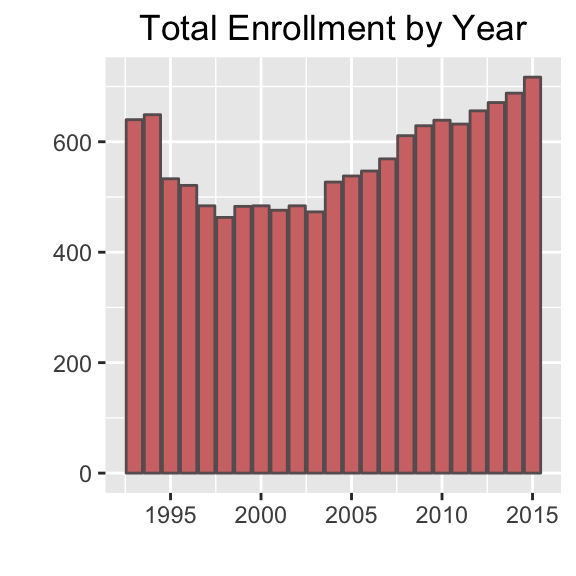

| Gender | Count | Percent |
| --- | --- | --- |
| Male | 359 | 50% |
| Female | 358 | 50% |

| Ethnicity | Count | Percent |
| --- | --- | --- |
| Not reported | 1 | 0% |
| Asian | 343 | 48% |
| Pacific Islander | 3 | 0% |
| Filipino | 32 | 4% |
| Hispanic or Latino | 60 | 8% |
| African American | 6 | 1% |
| White | 207 | 29% |
| Two or More Races | 65 | 9% |

### Baywood Elementary

- Street address: 600 Alameda de Las Pulgas
- San Mateo CA 94402-3358
- Phone: (650) 312-7511
- Website: http://baywood.smfc.k12.ca.us/
- Open Date: 1980-07-01
- Charter: N
- Grades Offered: K-5
- Grades Served: K-5
- Virtual: N
- Magnet: N

Map

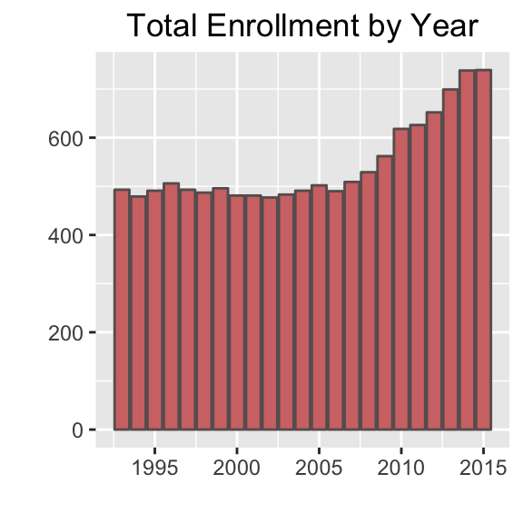

| Gender | Count | Percent |
| --- | --- | --- |
| Male | 380 | 51% |
| Female | 359 | 49% |

| Ethnicity | Count | Percent |
| --- | --- | --- |
| Not reported | 2 | 0% |
| Asian | 124 | 17% |
| Pacific Islander | 2 | 0% |
| Filipino | 22 | 3% |
| Hispanic or Latino | 189 | 26% |
| African American | 3 | 0% |
| White | 336 | 45% |
| Two or More Races | 61 | 8% |

### Beresford Elementary

- Street address: 300 28th Avenue
- San Mateo CA 94403-2405
- Phone: (650) 312-7551
- Website: http://beresford.smfcsd.net
- Open Date: 1998-08-31
- Charter: N
- Grades Offered: K-5
- Grades Served: K-5
- Virtual: N
- Magnet: N

Map

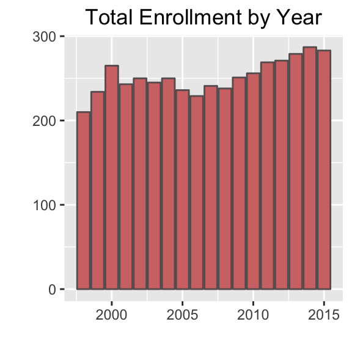

| Gender | Count | Percent |
| --- | --- | --- |
| Male | 147 | 52% |
| Female | 136 | 48% |

| Ethnicity | Count | Percent |
| --- | --- | --- |
| Asian | 18 | 6% |
| Pacific Islander | 6 | 2% |
| Filipino | 12 | 4% |
| Hispanic or Latino | 137 | 48% |
| African American | 4 | 1% |
| White | 89 | 31% |
| Two or More Races | 17 | 6% |

### Brewer Island Elementary

- Street address: 1151 Polynesia Drive
- Foster City CA 94404-1749
- Phone: (650) 312-7532
- Website: http://brewer-island.smfcsd.net
- Open Date: 1995-08-30
- Charter: N
- Grades Offered: K-5
- Grades Served: K-5
- Virtual: N
- Magnet: N

Map

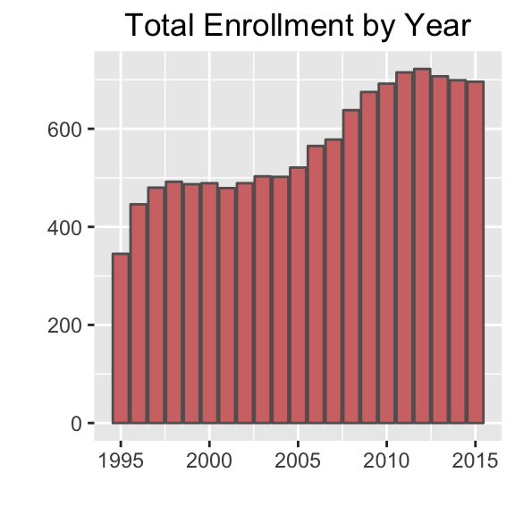

| Gender | Count | Percent |
| --- | --- | --- |
| Male | 340 | 49% |
| Female | 356 | 51% |

| Ethnicity | Count | Percent |
| --- | --- | --- |
| Not reported | 1 | 0% |
| American Indian or Alaska Native | 1 | 0% |
| Asian | 435 | 62% |
| Pacific Islander | 2 | 0% |
| Filipino | 34 | 5% |
| Hispanic or Latino | 55 | 8% |
| African American | 8 | 1% |
| White | 110 | 16% |
| Two or More Races | 50 | 7% |

### College Park Elementary

- Street address: 715-A Indian Avenue
- San Mateo CA 94401-1768
- Phone: (650) 312-7691
- Website: http://college-park.smfcsd.net
- Open Date: 1980-07-01
- Charter: N
- Grades Offered: K-5
- Grades Served: K-5
- Virtual: N
- Magnet: Y

Map

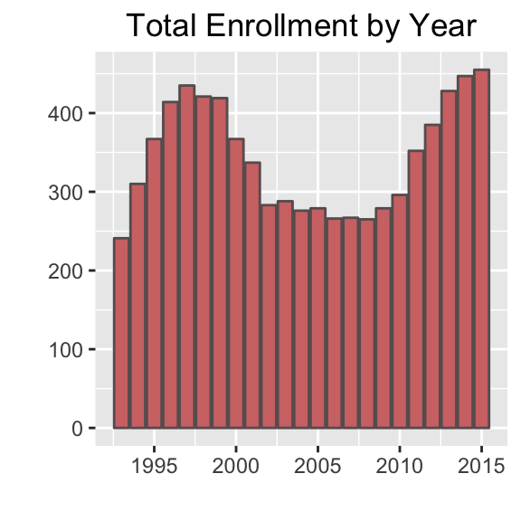

| Gender | Count | Percent |
| --- | --- | --- |
| Male | 214 | 47% |
| Female | 241 | 53% |

| Ethnicity | Count | Percent |
| --- | --- | --- |
| American Indian or Alaska Native | 2 | 0% |
| Asian | 290 | 64% |
| Pacific Islander | 1 | 0% |
| Filipino | 13 | 3% |
| Hispanic or Latino | 24 | 5% |
| African American | 2 | 0% |
| White | 42 | 9% |
| Two or More Races | 81 | 18% |

### Fiesta Gardens International Elementary

- Street address: 1001 Bermuda Drive
- San Mateo CA 94403-1508
- Phone: (650) 312-7737
- Website: http://fiesta-gardens.smfcsd.net
- Open Date: 1993-09-01
- Charter: N
- Grades Offered: K-5
- Grades Served: K-5
- Virtual: N
- Magnet: Y

Map

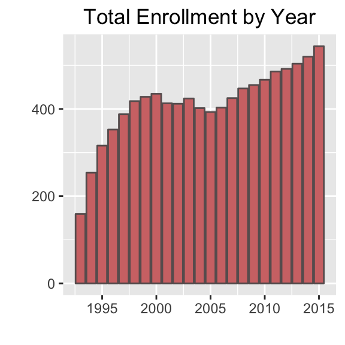

| Gender | Count | Percent |
| --- | --- | --- |
| Male | 244 | 45% |
| Female | 300 | 55% |

| Ethnicity | Count | Percent |
| --- | --- | --- |
| Asian | 1 | 0% |
| Pacific Islander | 4 | 1% |
| Filipino | 2 | 0% |
| Hispanic or Latino | 439 | 81% |
| African American | 2 | 0% |
| White | 77 | 14% |
| Two or More Races | 19 | 3% |

### Foster City Elementary

- Street address: 461 Beach Park Boulevard
- Foster City CA 94404-2713
- Phone: (650) 312-7522
- Website: http://fostercity.smfc.k12.ca.us/
- Open Date: 1980-07-01
- Charter: N
- Grades Offered: K-5
- Grades Served: K-5
- Virtual: N
- Magnet: N

Map

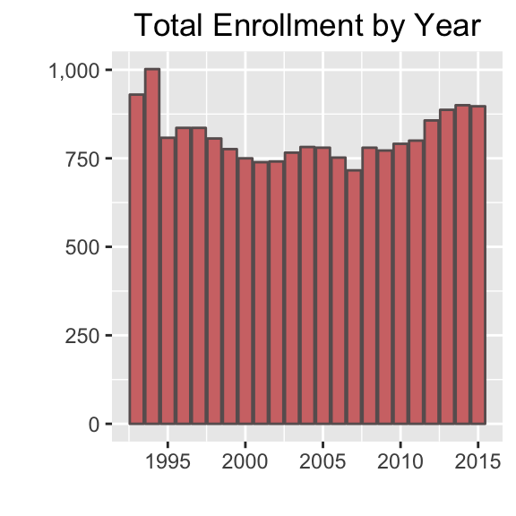

| Gender | Count | Percent |
| --- | --- | --- |
| Male | 489 | 55% |
| Female | 408 | 45% |

| Ethnicity | Count | Percent |
| --- | --- | --- |
| Not reported | 4 | 0% |
| American Indian or Alaska Native | 1 | 0% |
| Asian | 483 | 54% |
| Pacific Islander | 2 | 0% |
| Filipino | 42 | 5% |
| Hispanic or Latino | 50 | 6% |
| African American | 8 | 1% |
| White | 228 | 25% |
| Two or More Races | 79 | 9% |

### George Hall Elementary

- Street address: 130 San Miguel Way
- San Mateo CA 94403-2954
- Phone: (650) 312-7533
- Website: http://georgehall.smfc.k12.ca.us/
- Open Date: 1980-07-01
- Charter: N
- Grades Offered: K-5
- Grades Served: K-5
- Virtual: N
- Magnet: Y

Map

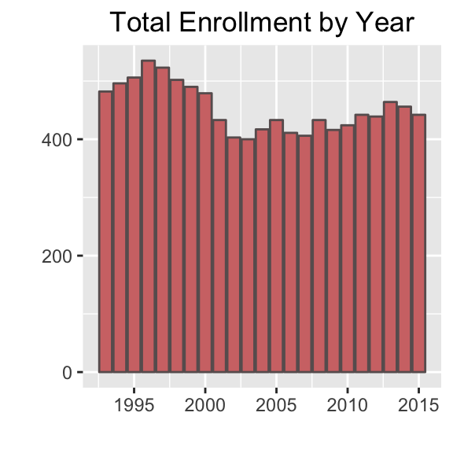

| Gender | Count | Percent |
| --- | --- | --- |
| Male | 229 | 52% |
| Female | 213 | 48% |

| Ethnicity | Count | Percent |
| --- | --- | --- |
| American Indian or Alaska Native | 1 | 0% |
| Asian | 59 | 13% |
| Pacific Islander | 16 | 4% |
| Filipino | 22 | 5% |
| Hispanic or Latino | 185 | 42% |
| African American | 17 | 4% |
| White | 117 | 26% |
| Two or More Races | 25 | 6% |

### Highlands Elementary

- Street address: 2320 Newport Street
- San Mateo CA 94402-3838
- Phone: (650) 312-7544
- Website: http://highlands.smfcsd.net
- Open Date: 1980-07-01
- Charter: N
- Grades Offered: K-5
- Grades Served: K-5
- Virtual: N
- Magnet: N

Map

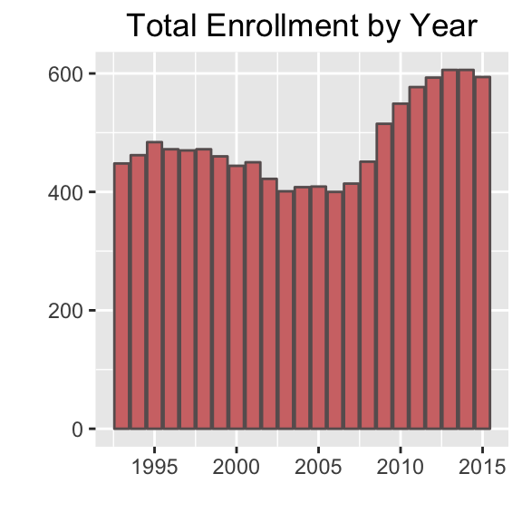

| Gender | Count | Percent |
| --- | --- | --- |
| Male | 303 | 51% |
| Female | 291 | 49% |

| Ethnicity | Count | Percent |
| --- | --- | --- |
| Asian | 104 | 18% |
| Filipino | 14 | 2% |
| Hispanic or Latino | 176 | 30% |
| African American | 8 | 1% |
| White | 223 | 38% |
| Two or More Races | 69 | 12% |

### Laurel Elementary

- Street address: 316 36th Avenue
- San Mateo CA 94403-4204
- Phone: (650) 312-7555
- Website: http://laurel.smfc.k12.ca.us/
- Open Date: 1980-07-01
- Charter: N
- Grades Offered: K-5
- Grades Served: K-5
- Virtual: N
- Magnet: N

Map

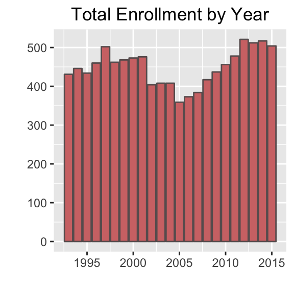

| Gender | Count | Percent |
| --- | --- | --- |
| Male | 256 | 51% |
| Female | 248 | 49% |

| Ethnicity | Count | Percent |
| --- | --- | --- |
| Not reported | 4 | 1% |
| American Indian or Alaska Native | 1 | 0% |
| Asian | 33 | 7% |
| Pacific Islander | 11 | 2% |
| Filipino | 19 | 4% |
| Hispanic or Latino | 239 | 47% |
| African American | 5 | 1% |
| White | 167 | 33% |
| Two or More Races | 25 | 5% |

### LEAD Elementary

- Street address: 949 Ocean View Avenue
- San Mateo CA 94401-3462
- Phone: (650) 312-7550
- Website: http://lead.smfcsd.net/
- Open Date: 1980-07-01
- Charter: N
- Grades Offered: K-5
- Grades Served: K-5
- Virtual: N
- Magnet: Y

Map

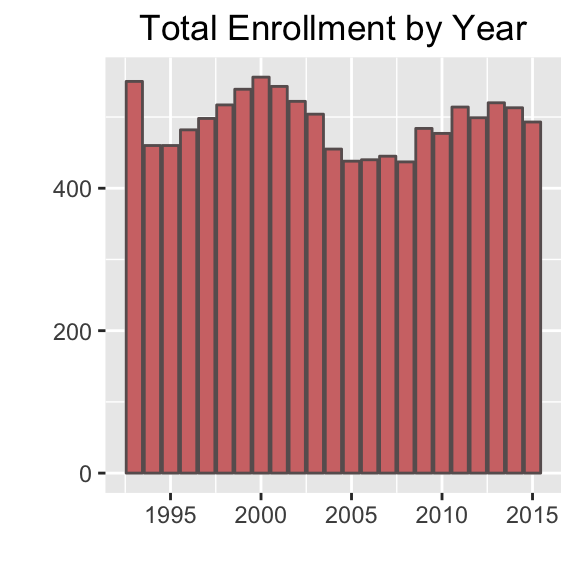

| Gender | Count | Percent |
| --- | --- | --- |
| Male | 263 | 53% |
| Female | 230 | 47% |

| Ethnicity | Count | Percent |
| --- | --- | --- |
| Not reported | 2 | 0% |
| American Indian or Alaska Native | 1 | 0% |
| Asian | 18 | 4% |
| Pacific Islander | 42 | 9% |
| Filipino | 13 | 3% |
| Hispanic or Latino | 337 | 68% |
| African American | 11 | 2% |
| White | 43 | 9% |
| Two or More Races | 26 | 5% |

### Meadow Heights Elementary

- Street address: 2619 Dolores Street
- San Mateo CA 94403-2644
- Phone: (650) 312-7566
- Website: http://meadowheights.smfc.k12.ca.us/
- Open Date: 1980-07-01
- Charter: N
- Grades Offered: K-5
- Grades Served: K-5
- Virtual: N
- Magnet: N

Map

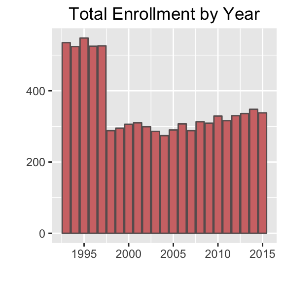

| Gender | Count | Percent |
| --- | --- | --- |
| Male | 190 | 56% |
| Female | 148 | 44% |

| Ethnicity | Count | Percent |
| --- | --- | --- |
| American Indian or Alaska Native | 1 | 0% |
| Asian | 41 | 12% |
| Pacific Islander | 13 | 4% |
| Filipino | 18 | 5% |
| Hispanic or Latino | 108 | 32% |
| African American | 4 | 1% |
| White | 121 | 36% |
| Two or More Races | 32 | 9% |

### North Shoreview Montessori Elementary

- Street address: 1301 Cypress Avenue
- San Mateo CA 94401-2007
- Phone: (650) 312-7588
- Website: http://northshoreview.smfc.k12.ca.us/
- Open Date: 1980-07-01
- Charter: N
- Grades Offered: K-8
- Grades Served: K-8
- Virtual: N
- Magnet: Y

Map

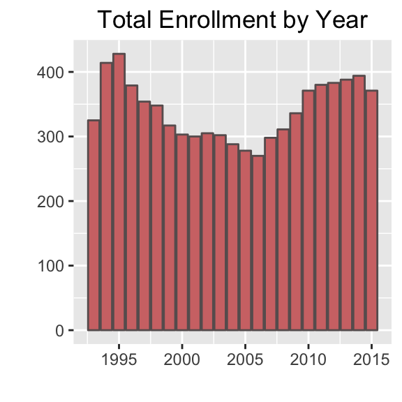

| Gender | Count | Percent |
| --- | --- | --- |
| Male | 192 | 52% |
| Female | 179 | 48% |

| Ethnicity | Count | Percent |
| --- | --- | --- |
| Not reported | 2 | 1% |
| Asian | 51 | 14% |
| Pacific Islander | 11 | 3% |
| Filipino | 15 | 4% |
| Hispanic or Latino | 84 | 23% |
| African American | 2 | 1% |
| White | 154 | 42% |
| Two or More Races | 52 | 14% |

### Parkside Elementary

- Street address: 1685 Eisenhower Street
- San Mateo CA 94402-1045
- Phone: (650) 312-7575
- Website: http://parkside.smfc.k12.ca.us/
- Open Date: 1980-07-01
- Charter: N
- Grades Offered: K-6
- Grades Served: K-5
- Virtual: N
- Magnet: Y

Map

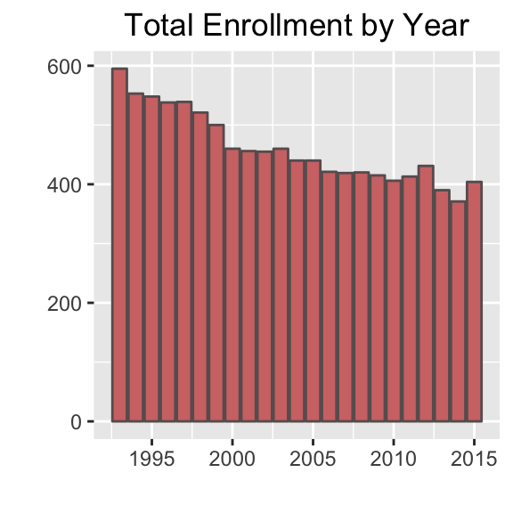

| Gender | Count | Percent |
| --- | --- | --- |
| Male | 228 | 56% |
| Female | 176 | 44% |

| Ethnicity | Count | Percent |
| --- | --- | --- |
| Asian | 52 | 13% |
| Pacific Islander | 46 | 11% |
| Filipino | 24 | 6% |
| Hispanic or Latino | 162 | 40% |
| African American | 11 | 3% |
| White | 79 | 20% |
| Two or More Races | 30 | 7% |

### San Mateo Park Elementary

- Street address: 161 Clark Drive
- San Mateo CA 94402-1002
- Phone: (650) 312-7577
- Website: http://san-mateo-park.smfcsd.net/
- Open Date: 1980-07-01
- Charter: N
- Grades Offered: K-5
- Grades Served: K-5
- Virtual: N
- Magnet: Y

Map

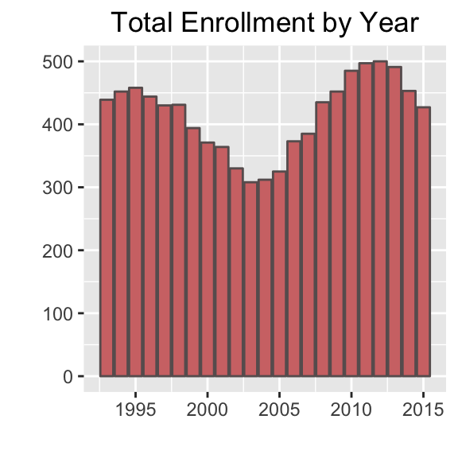

| Gender | Count | Percent |
| --- | --- | --- |
| Male | 244 | 57% |
| Female | 183 | 43% |

| Ethnicity | Count | Percent |
| --- | --- | --- |
| Not reported | 5 | 1% |
| Asian | 11 | 3% |
| Pacific Islander | 7 | 2% |
| Filipino | 20 | 5% |
| Hispanic or Latino | 285 | 67% |
| African American | 5 | 1% |
| White | 68 | 16% |
| Two or More Races | 26 | 6% |

### Sunnybrae Elementary

Map

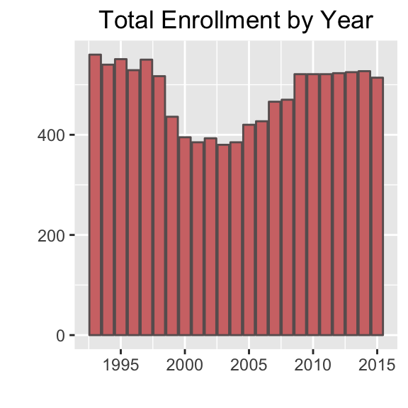

| Gender | Count | Percent |
| --- | --- | --- |
| Male | 246 | 48% |
| Female | 268 | 52% |

| Ethnicity | Count | Percent |
| --- | --- | --- |
| Not reported | 2 | 0% |
| American Indian or Alaska Native | 2 | 0% |
| Asian | 17 | 3% |
| Pacific Islander | 21 | 4% |
| Filipino | 32 | 6% |
| Hispanic or Latino | 334 | 65% |
| African American | 11 | 2% |
| White | 70 | 14% |
| Two or More Races | 25 | 5% |

### Abbott Middle

- Street address: 600 36th Avenue
- San Mateo CA 94403-4101
- Phone: (650) 312-7600
- Website: http://abbott.smfcsd.net
- Open Date: 1980-07-01
- Charter: N
- Grades Offered: 6-8
- Grades Served: 6-8
- Virtual: N
- Magnet: Y

Map

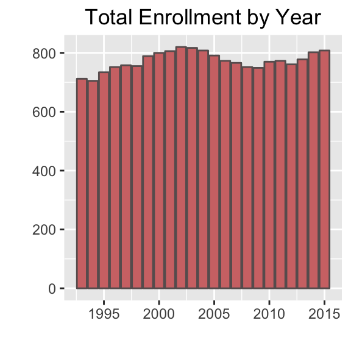

| Gender | Count | Percent |
| --- | --- | --- |
| Male | 409 | 51% |
| Female | 399 | 49% |

| Ethnicity | Count | Percent |
| --- | --- | --- |
| Not reported | 4 | 0% |
| Asian | 78 | 10% |
| Pacific Islander | 7 | 1% |
| Filipino | 47 | 6% |
| Hispanic or Latino | 420 | 52% |
| African American | 8 | 1% |
| White | 219 | 27% |
| Two or More Races | 25 | 3% |

### Bayside S.T.E.M. ACADEMY

- Street address: 2025 Kehoe Avenue
- San Mateo CA 94403-1061
- Phone: (650) 312-7660
- Website: http://bayside.smfcsd.net/
- Open Date: 1980-07-01
- Charter: N
- Grades Offered: 6-8
- Grades Served: 6-8
- Virtual: N
- Magnet: Y

Map

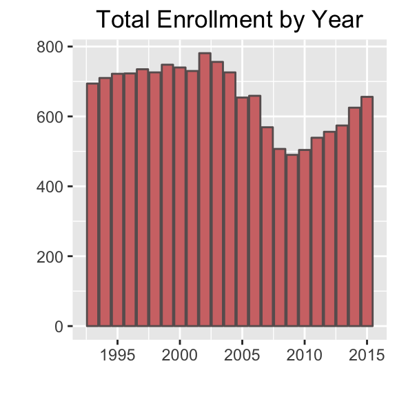

| Gender | Count | Percent |
| --- | --- | --- |
| Male | 335 | 51% |
| Female | 321 | 49% |

| Ethnicity | Count | Percent |
| --- | --- | --- |
| Not reported | 2 | 0% |
| American Indian or Alaska Native | 2 | 0% |
| Asian | 129 | 20% |
| Pacific Islander | 63 | 10% |
| Filipino | 31 | 5% |
| Hispanic or Latino | 278 | 42% |
| African American | 8 | 1% |
| White | 114 | 17% |
| Two or More Races | 29 | 4% |

### Borel Middle

- Street address: 425 Barneson Avenue
- San Mateo CA 94402-3405
- Phone: (650) 312-7670
- Website: http://borel.smfc.k12.ca.us/
- Open Date: 1980-07-01
- Charter: N
- Grades Offered: 6-8
- Grades Served: 6-8
- Virtual: N
- Magnet: Y

Map

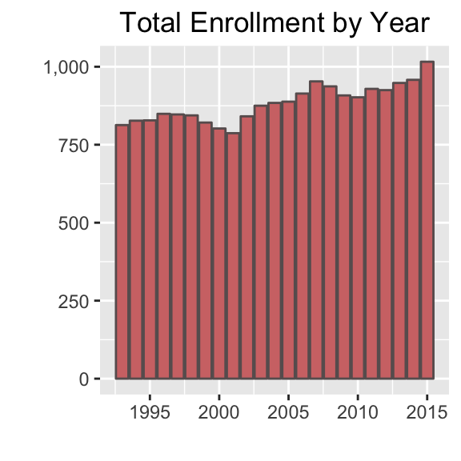

| Gender | Count | Percent |
| --- | --- | --- |
| Male | 498 | 49% |
| Female | 518 | 51% |

| Ethnicity | Count | Percent |
| --- | --- | --- |
| Not reported | 3 | 0% |
| American Indian or Alaska Native | 1 | 0% |
| Asian | 121 | 12% |
| Pacific Islander | 18 | 2% |
| Filipino | 38 | 4% |
| Hispanic or Latino | 440 | 43% |
| African American | 15 | 1% |
| White | 331 | 33% |
| Two or More Races | 49 | 5% |

### Bowditch Middle

- Street address: 1450 Tarpon Street
- Foster City CA 94404-1938
- Phone: (650) 312-7680
- Website: http://bowditch.smfc.k12.ca.us/
- Open Date: 1980-07-01
- Charter: N
- Grades Offered: 6-8
- Grades Served: 6-8
- Virtual: N
- Magnet: N

Map

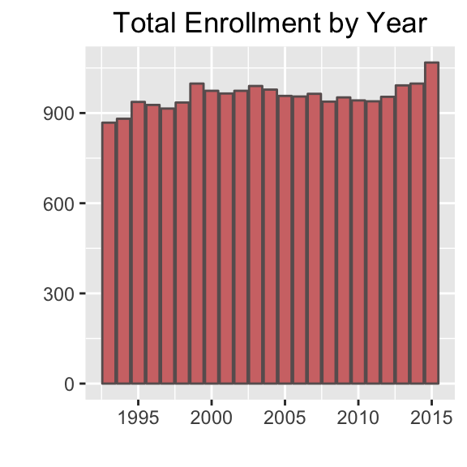

| Gender | Count | Percent |
| --- | --- | --- |
| Male | 542 | 51% |
| Female | 526 | 49% |

| Ethnicity | Count | Percent |
| --- | --- | --- |
| Not reported | 2 | 0% |
| Asian | 509 | 48% |
| Pacific Islander | 12 | 1% |
| Filipino | 56 | 5% |
| Hispanic or Latino | 87 | 8% |
| African American | 9 | 1% |
| White | 311 | 29% |
| Two or More Races | 82 | 8% |